# 10 Synthetic Control

Notice that in addition to the figure, this created an Excel spreadsheet containing information on the pre-RMSPE, the post-RMSPE, the ratio, and the rank. We will want to use that again when we limit our display next to states whose pre-RMSPE are similar to that of Texas.

Now we want to create the characteristic placebo graph where all the state placebos are laid on top of Texas. To do that, we can use some simple syntax contained in the Stata code:

**Stata Code**

synth_7.do

```stata
* Inference 3: all the placeboes on the same picture
use ../data/synth/placebo_bmprate.dta, replace
* Picture of the full sample, including outlier RSMPE
#delimit;
twoway
(line gap1 year ,lp(solid)lw(vthin))
(line gap2 year ,lp(solid)lw(vthin))
(line gap4 year ,lp(solid)lw(vthin))
(line gap5 year ,lp(solid)lw(vthin))
(line gap6 year ,lp(solid)lw(vthin))
(line gap8 year ,lp(solid)lw(vthin))
(line gap9 year ,lp(solid)lw(vthin))
(line gap10 year ,lp(solid)lw(vthin))
(line gap11 year ,lp(solid)lw(vthin))
(line gap12 year ,lp(solid)lw(vthin))
(line gap13 year ,lp(solid)lw(vthin))
(line gap15 year ,lp(solid)lw(vthin))
(line gap16 year ,lp(solid)lw(vthin))
(line gap17 year ,lp(solid)lw(vthin))
(line gap18 year ,lp(solid)lw(vthin))
(line gap20 year ,lp(solid)lw(vthin))
(line gap21 year ,lp(solid)lw(vthin))
(line gap22 year ,lp(solid)lw(vthin))
(line gap23 year ,lp(solid)lw(vthin))
(line gap24 year ,lp(solid)lw(vthin))
(line gap25 year ,lp(solid)lw(vthin))
(line gap26 year ,lp(solid)lw(vthin))
(line gap27 year ,lp(solid)lw(vthin))
(line gap28 year ,lp(solid)lw(vthin))
(line gap29 year ,lp(solid)lw(vthin))
(line gap30 year ,lp(solid)lw(vthin))
(line gap31 year ,lp(solid)lw(vthin))
(line gap32 year ,lp(solid)lw(vthin))
(line gap33 year ,lp(solid)lw(vthin))
(line gap34 year ,lp(solid)lw(vthin))
(line gap35 year ,lp(solid)lw(vthin))
(line gap36 year ,lp(solid)lw(vthin))
(line gap37 year ,lp(solid)lw(vthin))
(line gap38 year ,lp(solid)lw(vthin))
(line gap39 year ,lp(solid)lw(vthin))
(line gap40 year ,lp(solid)lw(vthin))
(line gap41 year ,lp(solid)lw(vthin))
(line gap42 year ,lp(solid)lw(vthin))
(line gap45 year ,lp(solid)lw(vthin))
(line gap46 year ,lp(solid)lw(vthin))
(line gap47 year ,lp(solid)lw(vthin))
(line gap49 year ,lp(solid)lw(vthin))
(line gap51 year ,lp(solid)lw(vthin))
(line gap53 year ,lp(solid)lw(vthin))
(line gap55 year ,lp(solid)lw(vthin))
(line gap48 year ,lp(solid)lw(thick)lcolor(black)), /*treatment unit, Texas*/
yline(0, lpattern(shortdash) lcolor(black)) xline(1993, lpattern(shortdash) lcolor(black))
xtitle("",si(small)) xlabel(#10) ytitle("Gap in black male prisoners prediction error", size(small))
    legend(off);
#delimit cr
```

Here we will only display the main picture with the placebos, though one could show several cuts of the data in which you drop states whose pre-treatment fit compared to Texas is rather poor.

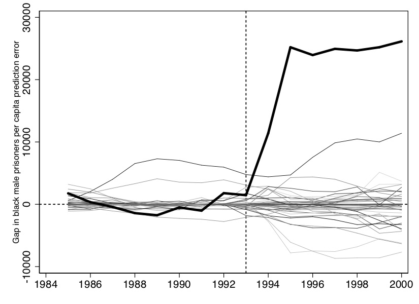

Figure 10.12: Placebo distribution. Texas is the black line.

Now that you have seen how to use this .do file to estimate a synthetic control model, you are ready to play around with the data yourself. All of this analysis so far has used black male (total counts) incarceration as the dependent variable, but perhaps the results would be different if we used black male incarceration. That information is contained in the data set. I would like for you to do your own analysis using the black male incarceration rate variable as the dependent variable. You will need to find a new model to fit this pattern, as it’s unlikely that the one we used for levels will do as good a job describing rates as it did levels. In addition, you should implement the placebo-date falsification exercise that we mentioned from Abadie, Diamond, and Hainmueller (2015). Choose 1989 as your treatment date and 1992 as the end of the sample, and check whether the same model shows the same treatment effect as you found when you used the correct year, 1993, as the treatment date. I encourage you to use these data and this file to learn the ins and outs of the procedure itself, as well as to think more deeply about what synthetic control is doing and how to best use it in research.

## 10.3 Conclusion

In conclusion, we have seen how to estimate synthetic control models in Stata. This model is currently an active area of research, and so I have decided to wait until subsequent editions to dive into the new material as many questions are unsettled. This chapter therefore is a good foundation for understanding the model and the practices around implementing it, including code in $R$ and Stata to do so. I hope that you find this useful.

[figure not shown]

Causal Inference: The Mixtape.

Buy the print version today:

[Buy from Amazon](https://www.amazon.com/dp/0300251688) [Buy from Yale Press](https://yalebooks.yale.edu/book/9780300251685/causal-inference)

[^1]: See Doudchenko and Imbens (2016) for work relaxing the non-negativity constraint.
[^2]: What we will do is simply reassign the treatment to each unit, putting California back into the donor pool each time, estimate the model for that “placebo,” and record information from each iteration.
[^3]: Recall, they dropped several states who had similar legislation passed over this time period.
[^4]: You can find one example of an unpublished manuscript here coauthored with Sam Kang: <www.scunning.com/files/mass_incarceration_and_drug_abuse.pdf>.